# Homework Assignment 1

Daniel Vasquez

Assigned: Oct 24, 2020, Due Sun Nov 01, 2020 11:59PM

```r
library(dplyr)
```

```r
library(ggplot2)
```

## Reading my data

```r
nyc <- read.csv("nycflights.csv")

# Quick exploration of the data
str(nyc)
```

```
## 'data.frame':    336776 obs. of  20 variables:
##  $ X             : int  1 2 3 4 5 6 7 8 9 10 ...
##  $ year          : int  2013 2013 2013 2013 2013 2013 2013 2013 2013 2013 ...
##  $ month         : int  1 1 1 1 1 1 1 1 1 1 ...
##  $ day           : int  1 1 1 1 1 1 1 1 1 1 ...
##  $ dep_time      : int  517 533 542 544 554 554 555 557 557 558 ...
##  $ sched_dep_time: int  515 529 540 545 600 558 600 600 600 600 ...
##  $ dep_delay     : int  2 4 2 -1 -6 -4 -5 -3 -3 -2 ...
##  $ arr_time      : int  830 850 923 1004 812 740 913 709 838 753 ...
##  $ sched_arr_time: int  819 830 850 1022 837 728 854 723 846 745 ...
##  $ arr_delay     : int  11 20 33 -18 -25 12 19 -14 -8 8 ...
##  $ carrier       : chr  "UA" "UA" "AA" "B6" ...
##  $ flight        : int  1545 1714 1141 725 461 1696 507 5708 79 301 ...
##  $ tailnum       : chr  "N14228" "N24211" "N619AA" "N804JB" ...
##  $ origin        : chr  "EWR" "LGA" "JFK" "JFK" ...
##  $ dest          : chr  "IAH" "IAH" "MIA" "BQN" ...
##  $ air_time      : int  227 227 160 183 116 150 158 53 140 138 ...
##  $ distance      : int  1400 1416 1089 1576 762 719 1065 229 944 733 ...
##  $ hour          : int  5 5 5 5 6 5 6 6 6 6 ...
##  $ minute        : int  15 29 40 45 0 58 0 0 0 0 ...
##  $ time_hour     : chr  "2013-01-01 05:00:00" "2013-01-01 05:00:00" "2013-01-01 05:00:00" "2013-01-01 05:00:00" ...
```

```r
summary(nyc)
```

```
##        X               year          month             day
##  Min.   :     1   Min.   :2013   Min.   : 1.000   Min.   : 1.00
##  1st Qu.: 84195   1st Qu.:2013   1st Qu.: 4.000   1st Qu.: 8.00
##  Median :168389   Median :2013   Median : 7.000   Median :16.00
##  Mean   :168389   Mean   :2013   Mean   : 6.549   Mean   :15.71
##  3rd Qu.:252582   3rd Qu.:2013   3rd Qu.:10.000   3rd Qu.:23.00
##  Max.   :336776   Max.   :2013   Max.   :12.000   Max.   :31.00
##
##     dep_time    sched_dep_time   dep_delay          arr_time    sched_arr_time
##  Min.   :   1   Min.   : 106   Min.   : -43.00   Min.   :   1   Min.   :   1
##  1st Qu.: 907   1st Qu.: 906   1st Qu.:  -5.00   1st Qu.:1104   1st Qu.:1124
##  Median :1401   Median :1359   Median :  -2.00   Median :1535   Median :1556
##  Mean   :1349   Mean   :1344   Mean   :  12.64   Mean   :1502   Mean   :1536
##  3rd Qu.:1744   3rd Qu.:1729   3rd Qu.:  11.00   3rd Qu.:1940   3rd Qu.:1945
##  Max.   :2400   Max.   :2359   Max.   :1301.00   Max.   :2400   Max.   :2359
##  NA's   :8255                  NA's   :8255      NA's   :8713
##    arr_delay          carrier              flight       tailnum
##  Min.   : -86.000   Length:336776      Min.   :   1   Length:336776
##  1st Qu.: -17.000   Class :character   1st Qu.: 553   Class :character
##  Median :  -5.000   Mode  :character   Median :1496   Mode  :character
##  Mean   :   6.895                      Mean   :1972
##  3rd Qu.:  14.000                      3rd Qu.:3465
##  Max.   :1272.000                      Max.   :8500
##  NA's   :9430
##     origin              dest              air_time        distance
##  Length:336776      Length:336776      Min.   : 20.0   Min.   :  17
##  Class :character   Class :character   1st Qu.: 82.0   1st Qu.: 502
##  Mode  :character   Mode  :character   Median :129.0   Median : 872
##                                        Mean   :150.7   Mean   :1040
##                                        3rd Qu.:192.0   3rd Qu.:1389
##                                        Max.   :695.0   Max.   :4983
##                                        NA's   :9430
##       hour           minute       time_hour
##  Min.   : 1.00   Min.   : 0.00   Length:336776
##  1st Qu.: 9.00   1st Qu.: 8.00   Class :character
##  Median :13.00   Median :29.00   Mode  :character
##  Mean   :13.18   Mean   :26.23
##  3rd Qu.:17.00   3rd Qu.:44.00
##  Max.   :23.00   Max.   :59.00
##
```

## Cleaning the data

```r
# Deleting the column X
nyc$X <- NULL

# Factorize columns that need to be a factor

nyc$origin <- as.factor(nyc$origin)
nyc$tailnum <- as.factor(nyc$tailnum)
nyc$month <- as.factor(nyc$month)
nyc$dest <- as.factor(nyc$dest)
nyc$carrier <- as.factor(nyc$carrier)
nyc$flight <- as.factor(nyc$flight)

# Re-check my data
str(nyc)
```

```
## 'data.frame':    336776 obs. of  19 variables:
##  $ year          : int  2013 2013 2013 2013 2013 2013 2013 2013 2013 2013 ...
##  $ month         : Factor w/ 12 levels "1","2","3","4",..: 1 1 1 1 1 1 1 1 1 1 ...
##  $ day           : int  1 1 1 1 1 1 1 1 1 1 ...
##  $ dep_time      : int  517 533 542 544 554 554 555 557 557 558 ...
##  $ sched_dep_time: int  515 529 540 545 600 558 600 600 600 600 ...
##  $ dep_delay     : int  2 4 2 -1 -6 -4 -5 -3 -3 -2 ...
##  $ arr_time      : int  830 850 923 1004 812 740 913 709 838 753 ...
##  $ sched_arr_time: int  819 830 850 1022 837 728 854 723 846 745 ...
##  $ arr_delay     : int  11 20 33 -18 -25 12 19 -14 -8 8 ...
##  $ carrier       : Factor w/ 16 levels "9E","AA","AS",..: 12 12 2 4 5 12 4 6 4 2 ...
##  $ flight        : Factor w/ 3844 levels "1","2","3","4",..: 1382 1545 1042 677 425 1527 469 3700 69 266 ...
##  $ tailnum       : Factor w/ 4043 levels "D942DN","N0EGMQ",..: 180 524 2401 3204 2661 1142 1829 3300 2207 1178 ...
##  $ origin        : Factor w/ 3 levels "EWR","JFK","LGA": 1 3 2 2 3 1 1 3 2 3 ...
##  $ dest          : Factor w/ 105 levels "ABQ","ACK","ALB",..: 44 44 59 13 5 70 36 43 55 70 ...
##  $ air_time      : int  227 227 160 183 116 150 158 53 140 138 ...
##  $ distance      : int  1400 1416 1089 1576 762 719 1065 229 944 733 ...
##  $ hour          : int  5 5 5 5 6 5 6 6 6 6 ...
##  $ minute        : int  15 29 40 45 0 58 0 0 0 0 ...
##  $ time_hour     : chr  "2013-01-01 05:00:00" "2013-01-01 05:00:00" "2013-01-01 05:00:00" "2013-01-01 05:00:00" ...
```

```r
summary(nyc)
```

```
##       year          month             day           dep_time    sched_dep_time
##  Min.   :2013   7      : 29425   Min.   : 1.00   Min.   :   1   Min.   : 106
##  1st Qu.:2013   8      : 29327   1st Qu.: 8.00   1st Qu.: 907   1st Qu.: 906
##  Median :2013   10     : 28889   Median :16.00   Median :1401   Median :1359
##  Mean   :2013   3      : 28834   Mean   :15.71   Mean   :1349   Mean   :1344
##  3rd Qu.:2013   5      : 28796   3rd Qu.:23.00   3rd Qu.:1744   3rd Qu.:1729
##  Max.   :2013   4      : 28330   Max.   :31.00   Max.   :2400   Max.   :2359
##                 (Other):163175                   NA's   :8255
##    dep_delay          arr_time    sched_arr_time   arr_delay
##  Min.   : -43.00   Min.   :   1   Min.   :   1   Min.   : -86.000
##  1st Qu.:  -5.00   1st Qu.:1104   1st Qu.:1124   1st Qu.: -17.000
##  Median :  -2.00   Median :1535   Median :1556   Median :  -5.000
##  Mean   :  12.64   Mean   :1502   Mean   :1536   Mean   :   6.895
##  3rd Qu.:  11.00   3rd Qu.:1940   3rd Qu.:1945   3rd Qu.:  14.000
##  Max.   :1301.00   Max.   :2400   Max.   :2359   Max.   :1272.000
##  NA's   :8255      NA's   :8713                  NA's   :9430
##     carrier          flight          tailnum       origin
##  UA     :58665   15     :   968   N725MQ :   575   EWR:120835
##  B6     :54635   27     :   898   N722MQ :   513   JFK:111279
##  EV     :54173   181    :   882   N723MQ :   507   LGA:104662
##  DL     :48110   301    :   871   N711MQ :   486
##  AA     :32729   161    :   786   N713MQ :   483
##  MQ     :26397   695    :   782   (Other):331700
##  (Other):62067   (Other):331589   NA's   :  2512
##       dest           air_time        distance         hour
##  ORD    : 17283   Min.   : 20.0   Min.   :  17   Min.   : 1.00
##  ATL    : 17215   1st Qu.: 82.0   1st Qu.: 502   1st Qu.: 9.00
##  LAX    : 16174   Median :129.0   Median : 872   Median :13.00
##  BOS    : 15508   Mean   :150.7   Mean   :1040   Mean   :13.18
##  MCO    : 14082   3rd Qu.:192.0   3rd Qu.:1389   3rd Qu.:17.00
##  CLT    : 14064   Max.   :695.0   Max.   :4983   Max.   :23.00
##  (Other):242450   NA's   :9430
##      minute       time_hour
##  Min.   : 0.00   Length:336776
##  1st Qu.: 8.00   Class :character
##  Median :29.00   Mode  :character
##  Mean   :26.23
##  3rd Qu.:44.00
##  Max.   :59.00
##
```

## Data Exploration

- How many airlines are there?
- There are 16 airlines.

```r
length(levels(factor(nyc$carrier)))
```

```
## [1] 16
```

- How many flights were there by the airline with code `OO`? (Hint: `nrow` can be useful here along with logical indexing)
- 32 flights were there by the airline with code `OO`.

```r
nrow(nyc[factor(nyc$carrier) == "OO",])
```

```
## [1] 32
```

- How long is the shortest flight out of any NYC airport? (Hint: `min` can be useful, remember to handle `NA` values)
- The shortest flight out of any NYC airport is 20 minutes.

```r
min(nyc$air_time, na.rm = TRUE)
```

```
## [1] 20
```

- How many flights were there by United Airlines (code: UA) on Jan 12th 2013?
- On January 12, 2013, there were 112 flights by United Airlines.

```r
nrow(nyc[nyc$carrier == "UA" & nyc$month == 1 & nyc$day == 12 & nyc$year ==2013, ])
```

```
## [1] 112
```

### Arrival Delay

```r
mean(nyc$arr_delay, na.rm = TRUE)
```

```
## [1] 6.895377
```

```r
median(nyc$arr_delay, na.rm = TRUE)
```

```
## [1] -5
```

- What can you say about the distribution of arrival delays?
- The mean is larger number than the median, providing rationale that big delays were longer by a greater margin compared to both shorter delays & early arrivals.

### Airline Performance

- Calculate average arrival delays by airline, show the results in a barplot.
- Code below calculates average arrival.

```r
ave_arr_delays <- tapply(nyc$arr_delay, nyc$carrier, mean, na.rm = TRUE)
```

- Bar Plot of Average Arrival Delays for all the Airlines.

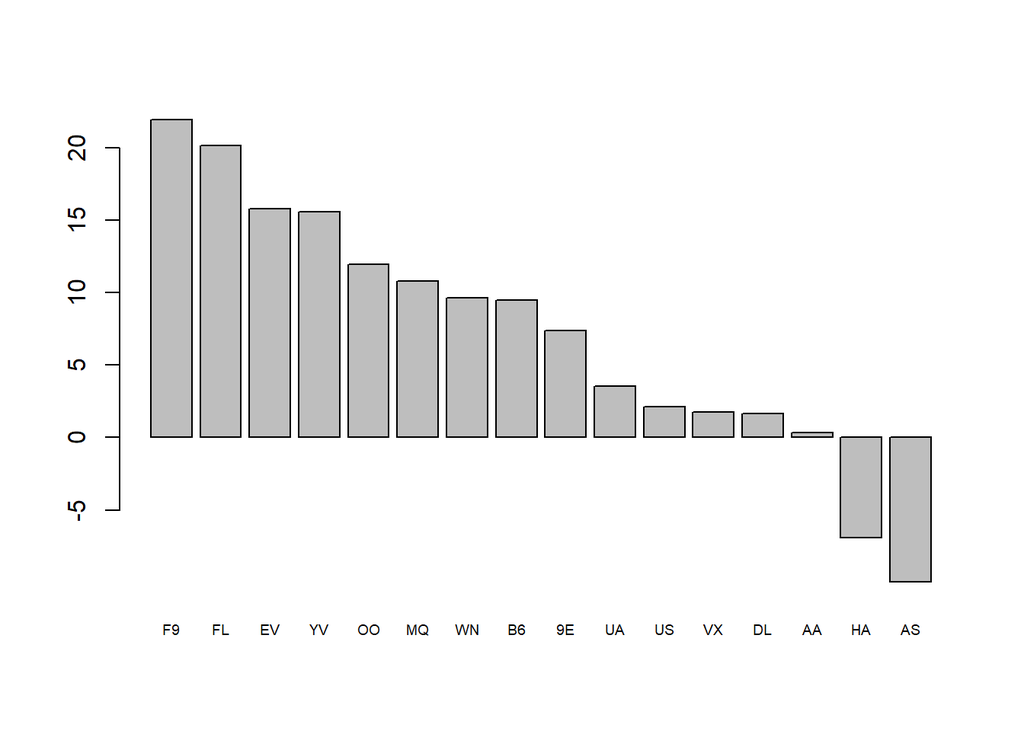

```r
barplot(sort(ave_arr_delays, decreasing = TRUE), cex.names = 0.6)
```

- Which airline has the highest average arrival delay? Which airline has the smallest average arrival delay? Are there airlines that actually have negative average delay?.

`Frontier Airlines had the highest average arrival delay.` `Alaska Airlines had the shortest average arrival delay.` `Native average delay means that the flights make up more time in the air, on average, than they lose in departure delays on the ground, making them early more often than not.` `It's a relatively isolated city and they're a relatively small carrier with long flights. They have more opportunities to make up time in the air.`

### Air Gain

Create a new column named airgain such that airgain = (departure delay - arrival delay) : this is the amount of delay a flight made up while in air.

```r
nyc$airgain <- nyc$dep_delay-nyc$arr_delay
```

- Explore airgain data - calculate suitable descriptive statistics and appropriate graphics to better understand this data.
- Distribution of Distances

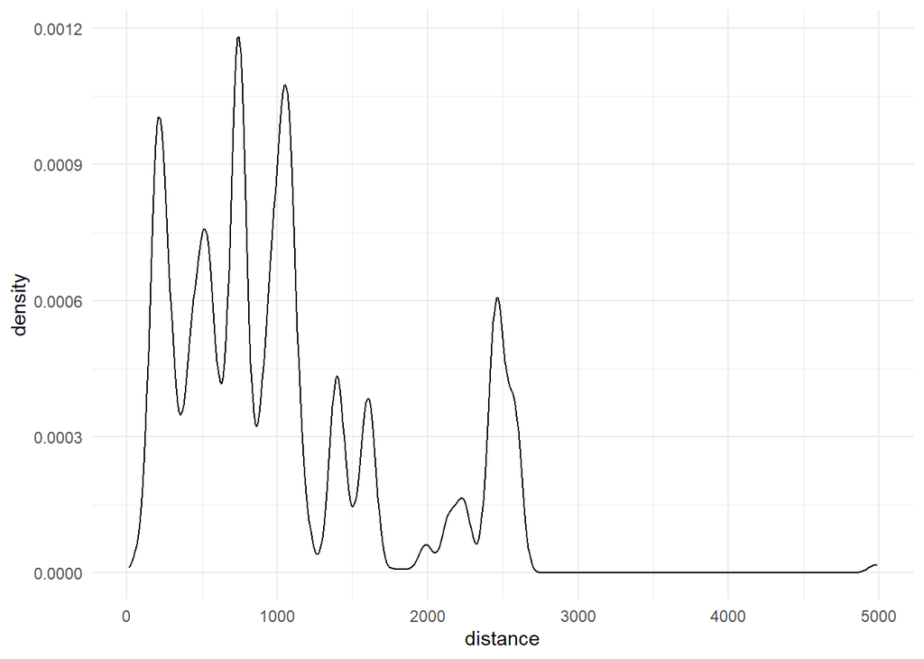

```r
nyc %>%
  ggplot(aes(x=distance)) + geom_density() +
  theme_minimal()
```

- Chart for Carriers, origin, and number of flights (n).

```r
nyc %>%
  group_by(origin) %>%
  count(carrier)
```

```
## # A tibble: 35 x 3
## # Groups:   origin [3]
##    origin carrier     n
##    <fct>  <fct>   <int>
##  1 EWR    9E       1268
##  2 EWR    AA       3487
##  3 EWR    AS        714
##  4 EWR    B6       6557
##  5 EWR    DL       4342
##  6 EWR    EV      43939
##  7 EWR    MQ       2276
##  8 EWR    OO          6
##  9 EWR    UA      46087
## 10 EWR    US       4405
## # ... with 25 more rows
```

- Figure #2

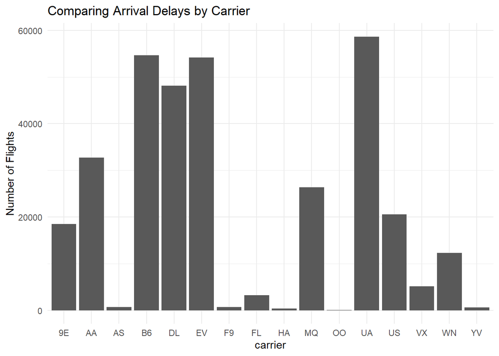

```r
nyc %>%
  ggplot(aes(x=carrier, fill=arr_delay)) +
  geom_bar() +
  labs(title = 'Comparing Arrival Delays by Carrier', y = 'Number of Flights') +
  theme_minimal()
```

- Do airlines actually gain any time when in air on average?
- Yes, airlines gain time when in the air, on average.

```r
meanairgain <- mean(nyc$airgain, na.rm = TRUE)
meanairgain
```

```
## [1] 5.659779
```

```r
#If else statement
if (meanairgain > 0) { print("Airline gained time in the air")} else { print("No, negative airgain")}
```

```
## [1] "Airline gained time in the air"
```

- Calculate average airgain for different airlines - which airlines do a better job, which do a worse job?
- See explanation below chart.

```r
avgairgainbyairline <- tapply(nyc$airgain, nyc$carrier, mean, na.rm = TRUE)
avgairgainbyairline
```

```
##         9E         AA         AS         B6         DL         EV         F9
##  9.0599052  8.2048393 15.7616361  3.5095746  7.5796089  4.0424982 -1.7195301
##         FL         HA         MQ         OO         UA         US         VX
## -1.5099213 11.8157895 -0.3293526  0.6551724  8.4588972  1.6150976 10.9921814
##         WN         YV
##  8.0125374  3.3419118
```

- Visualization to answer pt2.

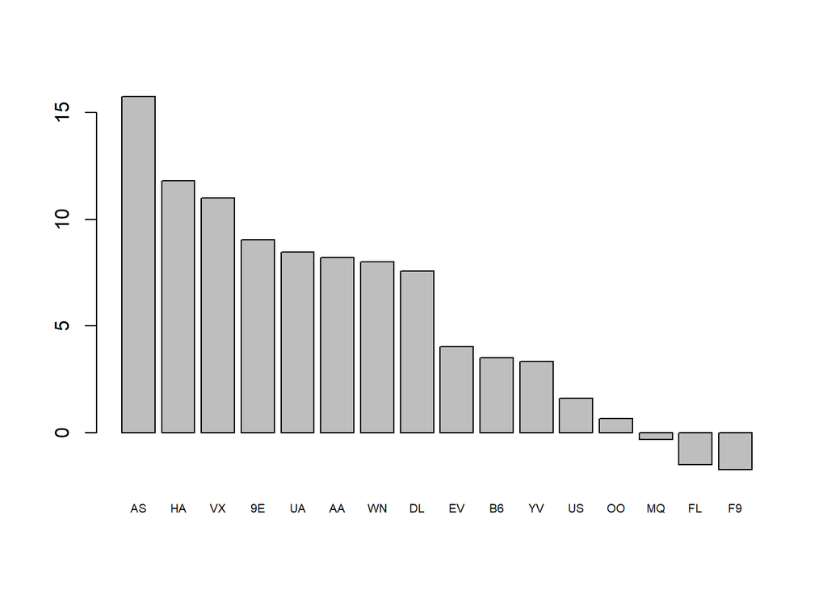

```r
barplot(sort(avgairgainbyairline, decreasing = TRUE), cex.names = 0.6)
```

- Visualization shows which airlines are good at catching up when in air and which airlines actually lose time further after taking off. AS, HA, and VX do the best while MQ, FL, and F9 do the worst.

### Merging Data Frames

-Read the data.

```r
planes <- read.csv("planes.csv")

# Deleting the column X.
planes$X <- NULL

# Factorize columns that need to be a factor

planes$tailnum <- as.factor(planes$tailnum)
planes$type <- as.factor(planes$type)
planes$manufacturer <- as.factor(planes$manufacturer)
planes$model <- as.factor(planes$model)
planes$engine <- as.factor(planes$engine)
planes$engines <- as.factor(planes$engines)

# Re-check my data
str(planes)
```

```
## 'data.frame':    3322 obs. of  9 variables:
##  $ tailnum     : Factor w/ 3322 levels "N10156","N102UW",..: 1 2 3 4 5 6 7 8 9 10 ...
##  $ year        : int  2004 1998 1999 1999 2002 1999 1999 1999 1999 1999 ...
##  $ type        : Factor w/ 3 levels "Fixed wing multi engine",..: 1 1 1 1 1 1 1 1 1 1 ...
##  $ manufacturer: Factor w/ 35 levels "AGUSTA SPA","AIRBUS",..: 18 3 3 3 18 3 3 3 3 3 ...
##  $ model       : Factor w/ 127 levels "150","172E","172M",..: 108 87 87 87 107 87 87 87 87 87 ...
##  $ engines     : Factor w/ 4 levels "1","2","3","4": 2 2 2 2 2 2 2 2 2 2 ...
##  $ seats       : int  55 182 182 182 55 182 182 182 182 182 ...
##  $ speed       : int  NA NA NA NA NA NA NA NA NA NA ...
##  $ engine      : Factor w/ 6 levels "4 Cycle","Reciprocating",..: 3 3 3 3 3 3 3 3 3 3 ...
```

```r
summary(planes)
```

```
##     tailnum          year                            type
##  N10156 :   1   Min.   :1956   Fixed wing multi engine :3292
##  N102UW :   1   1st Qu.:1997   Fixed wing single engine:  25
##  N103US :   1   Median :2001   Rotorcraft              :   5
##  N104UW :   1   Mean   :2000
##  N10575 :   1   3rd Qu.:2005
##  N105UW :   1   Max.   :2013
##  (Other):3316   NA's   :70
##             manufacturer          model      engines      seats
##  BOEING           :1630   737-7H4    : 361   1:  27   Min.   :  2.0
##  AIRBUS INDUSTRIE : 400   A320-232   : 256   2:3288   1st Qu.:140.0
##  BOMBARDIER INC   : 368   CL-600-2B19: 171   3:   3   Median :149.0
##  AIRBUS           : 336   CL-600-2D24: 123   4:   4   Mean   :154.3
##  EMBRAER          : 299   737-824    : 122            3rd Qu.:182.0
##  MCDONNELL DOUGLAS: 120   MD-88      : 117            Max.   :450.0
##  (Other)          : 169   (Other)    :2172
##      speed                 engine
##  Min.   : 90.0   4 Cycle      :   2
##  1st Qu.:107.5   Reciprocating:  28
##  Median :162.0   Turbo-fan    :2750
##  Mean   :236.8   Turbo-jet    : 535
##  3rd Qu.:432.0   Turbo-prop   :   2
##  Max.   :432.0   Turbo-shaft  :   5
##  NA's   :3299
```

- Merge the flights data and the planes data.

```r
nycplanes <- merge(x = nyc, y=planes,
                   by = "tailnum", all = TRUE)
```

## Exploratory Analysis

- What is the 90th percentile of airgain for different manufacturers?
- See chart below for the list in descending order.

```r
nycplanes %>%
  group_by(manufacturer) %>%
  summarise(airgain90=quantile(airgain, 0.9, na.rm=TRUE)) %>%
  arrange(desc(airgain90))
```

```
## # A tibble: 36 x 2
##    manufacturer          airgain90
##    <fct>                     <dbl>
##  1 BELL                       34.8
##  2 AMERICAN AIRCRAFT INC      34.6
##  3 SIKORSKY                   33
##  4 DEHAVILLAND                32
##  5 PIPER                      32
##  6 BOEING                     30
##  7 MCDONNELL DOUGLAS          30
##  8 BOMBARDIER INC             29
##  9 FRIEDEMANN JON             29
## 10 STEWART MACO               29
## # ... with 26 more rows
```

```r
nycplanes %>%
  filter(origin == 'LGA') %>%
  group_by(engines) %>%
  summarize(number_of_planes=n())
```

```
## # A tibble: 5 x 2
##   engines number_of_planes
##   <fct>              <int>
## 1 1                    966
## 2 2                  74091
## 3 3                      4
## 4 4                     40
## 5 <NA>               29561
```

```r
nycplanes %>%
  group_by(seats) %>%
  summarize(count = n()) %>%
  arrange(desc(seats)) %>%
  slice(2)
```

```
## # A tibble: 1 x 2
##   seats count
##   <int> <int>
## 1   400    29
```

- What is the mean and median speed for American Airline flights with a destination at O’Hare International Airport?
- For speed, the mean is 108.8 and the median is 95.

```r
nycplanes %>%
  filter(carrier == 'AA',
         dest == 'ORD') %>%
  summarize(mean = mean(speed, na.rm = TRUE), median = median(speed, na.rm=TRUE))
```

```
##       mean median
## 1 108.8239     95
```

- Should I fly in morning (4am - 12Noon), afternoon (12Noon - 4pm), evening (4pm - 8pm) or night (8pm - 4am) if I want to experience the least amount of arrival delay? [Use piping and ‘mutate’ command]
- Flying in the morning results in fewer delays.

```r
nycplanes %>%
  mutate(timeofday =
           case_when(nycplanes$hour >= 4 & nycplanes$hour <= 12 ~'morning',
                     nycplanes$hour > 12 & nycplanes$hour <= 16 ~'afternoon',
                     nycplanes$hour > 16 & nycplanes$hour <= 20 ~'evening',
                     nycplanes$hour > 20 & nycplanes$hour <= 24 ~'night')) %>%
  group_by(timeofday) %>%
  summarize(mean_of_arrival_delay = mean(arr_delay, na.rm=TRUE))
```

```
## # A tibble: 5 x 2
##   timeofday mean_of_arrival_delay
##   <chr>                     <dbl>
## 1 afternoon                 10.3
## 2 evening                   16.0
## 3 morning                   -1.18
## 4 night                     17.5
## 5 <NA>                     NaN
```